# Describing and Fitting Bayesian Models

R Pruim

February 8, 2017

## The Howell data

Nancy Howell collected data on !Kung San, one of the most famous foraging populations of the 20th century (in part because of her work and the work of other antroplogists who studied them).

### Let’s use only adults

```r
HowellAdults <-
  Howell1 %>% filter(age >= 18)
```

## Fitting a normal model

### The basic model

- $h_i \sim Norm(\mu, \sigma)$ (heights are normally distributed)
- $\mu \sim Norm(178, 20)$ (based on textbook author’s hieght)
- $\sigma \sim Unif(0, 50)$ (positive, but not known very well)

### Fitting the model (Grid Method)

We need to do some tricks to make the compuations work. The main trick is to work on the log scale. A secondary trick is to rescale the raw posterior to avoid getting values that are too small to add well.

But firs we need to create a function that allows us to use all of the data with each of several values of `mu` and `sigma`.

```r
llnorm <- function(x, mu, sigma) {
  sum(dnorm(x, mean = mu, sd = sigma, log = TRUE))
}
# use all of x for each mu-sigma combo
llnorm <- Vectorize(llnorm, c("mu", "sigma"))
```

Now we can fit the model.

```r
HowellAdultsGrid <-
  expand.grid(
    mu = seq(from = 178 - 40, to = 178 + 40, by = 0.1),
    sigma = seq(from = 0.2, to = 50, by = 0.1)) %>%  # be sure to avoid 0 here!
  mutate(
    logprior =
      dnorm(mu, 178, 20, log = TRUE) +
      dunif(sigma, 0, 50, log = TRUE),
    loglik = llnorm(HowellAdults$height, mu, sigma),
    posterior.log = logprior + loglik,
    posterior.raw = exp(posterior.log - max(posterior.log)),
    posterior = posterior.raw / sum(posterior.raw)
  )
```

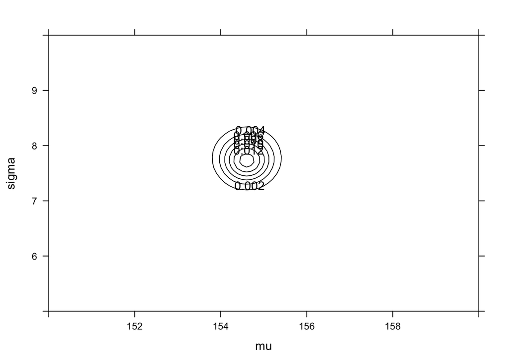

```r
contourplot(posterior ~ mu + sigma, data = HowellAdultsGrid,
             xlim = c(150, 160), ylim = c(5, 10))
```

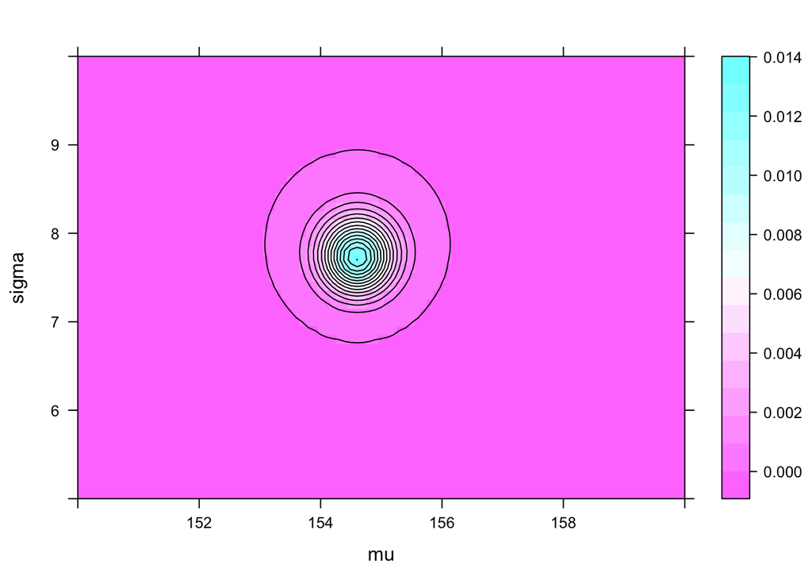

```r
levelplot(posterior ~ mu + sigma, data = HowellAdultsGrid, contour = TRUE,
          xlim = c(150, 160), ylim = c(5, 10))
```

```r
HowellAdultsPost <-
  sample(HowellAdultsGrid, size = 1e4, replace = TRUE,
         prob = HowellAdultsGrid$posterior)
```

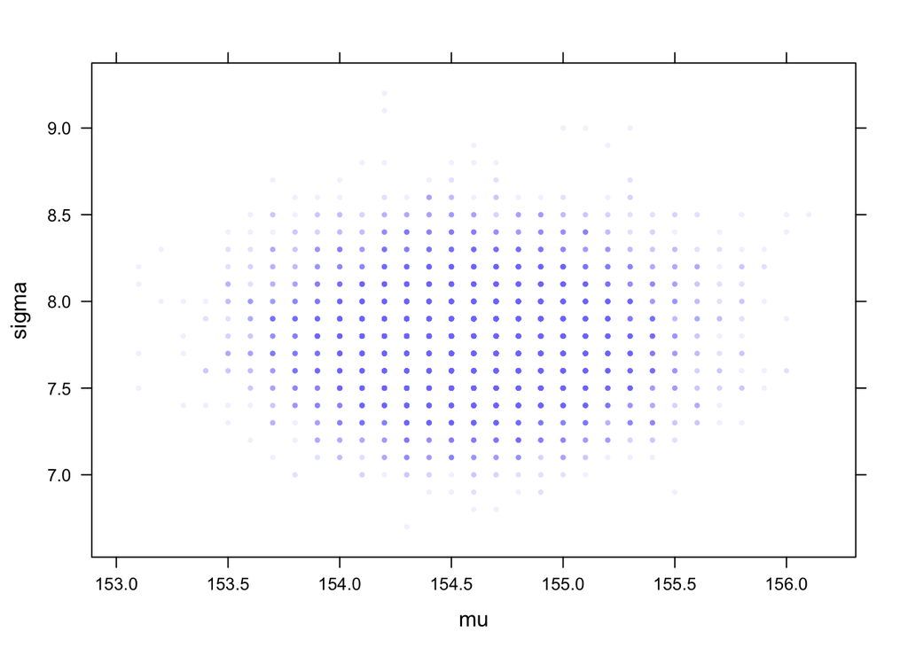

```r
xyplot(sigma ~  mu, data = HowellAdultsPost,
  cex = 0.5,
  pch = 16,
  col = col.alpha(rangi2, 0.1)
)
```

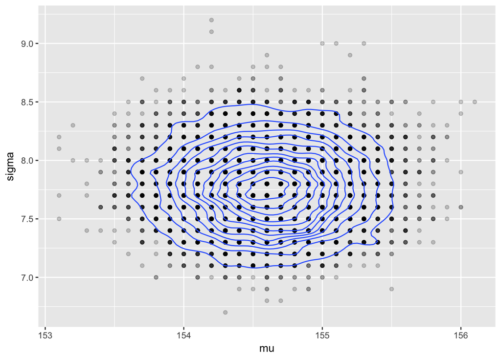

```r
ggplot(HowellAdultsPost, aes(x = mu, y = sigma)) +
  geom_point(alpha = 0.2) +
  geom_density2d()
```

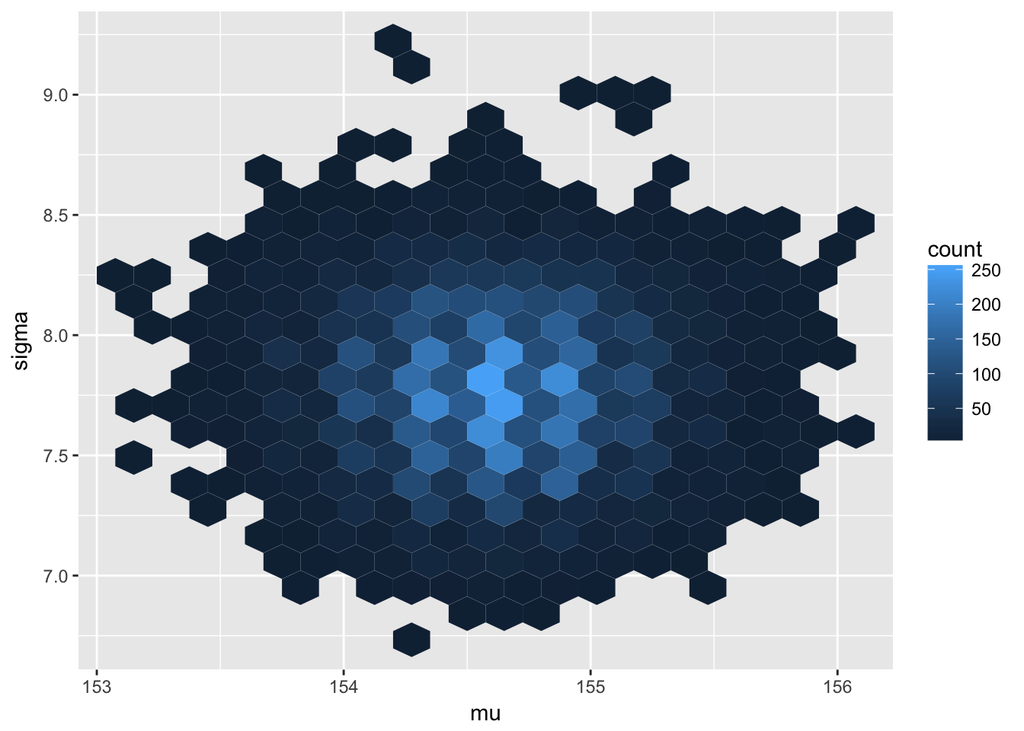

```r
ggplot(HowellAdultsPost, aes(x = mu, y = sigma)) +
  geom_hex(bins = 20)
```

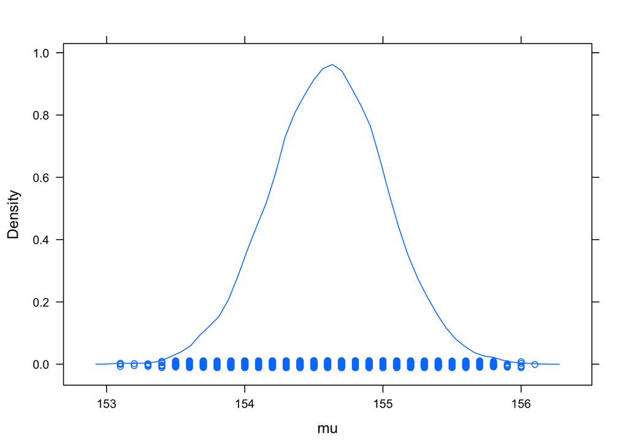

```r
densityplot( ~ mu, data = HowellAdultsPost)
```

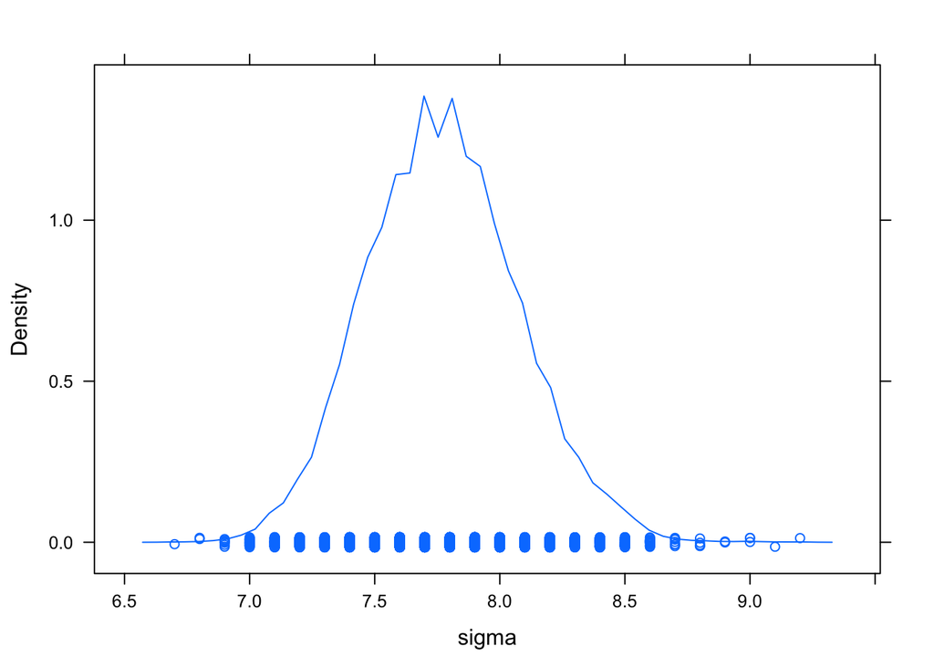

```r
densityplot( ~ sigma, data = HowellAdultsPost)
```

```r
HPDI(HowellAdultsPost$mu)
```

```
## |0.89 0.89|
## 153.9 155.2
```

```r
HPDI(HowellAdultsPost$sigma)
```

```
## |0.89 0.89|
##   7.3   8.2
```

## Let’s do it again with a smaller sample (n = 20)

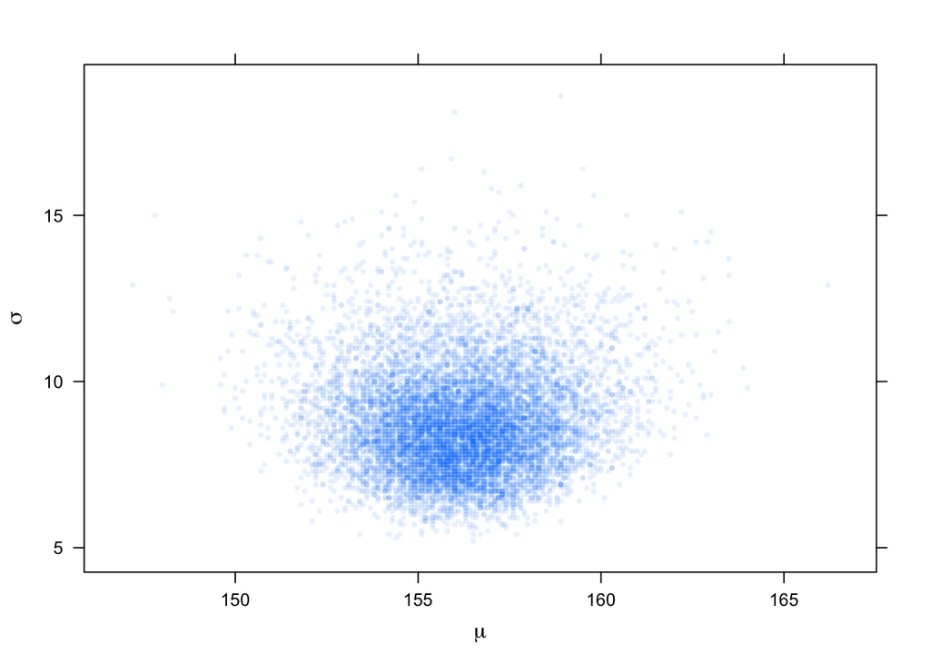

```r
Howell20 <- sample(HowellAdults, 20)

Howell20Grid <-
  expand.grid(
    mu = seq(from = 130, to = 170, by = 0.1),
    sigma = seq(from = 0.2, to = 50, by = 0.1)) %>%
  mutate(
    logprior =
      dnorm(mu, 178, 20, log = TRUE) +
      dunif(sigma, 0, 50, log = TRUE),
    loglik = llnorm(Howell20$height, mu, sigma),  # llnorm defined above
    posterior.log = logprior + loglik,
    posterior.raw = exp(posterior.log - max(posterior.log)),
    posterior = posterior.raw / sum(posterior.raw)
  )

Howell20.post <-
  sample(Howell20Grid, size = 1e4,
         replace = TRUE,
         prob = Howell20Grid$posterior)

xyplot(sigma ~ mu, data = Howell20.post,
  cex = 0.5, alpha = 0.1,
  xlab = expression(mu), ylab = expression(sigma),
  pch = 16
)
```

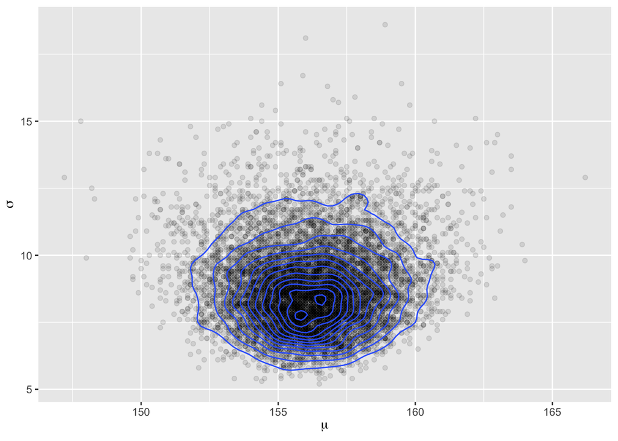

```r
ggplot(Howell20.post, aes(x = mu, y = sigma)) +
  geom_point(alpha = 0.1) +
  geom_density2d() +
  labs(x = expression(mu), y = expression(sigma))
```

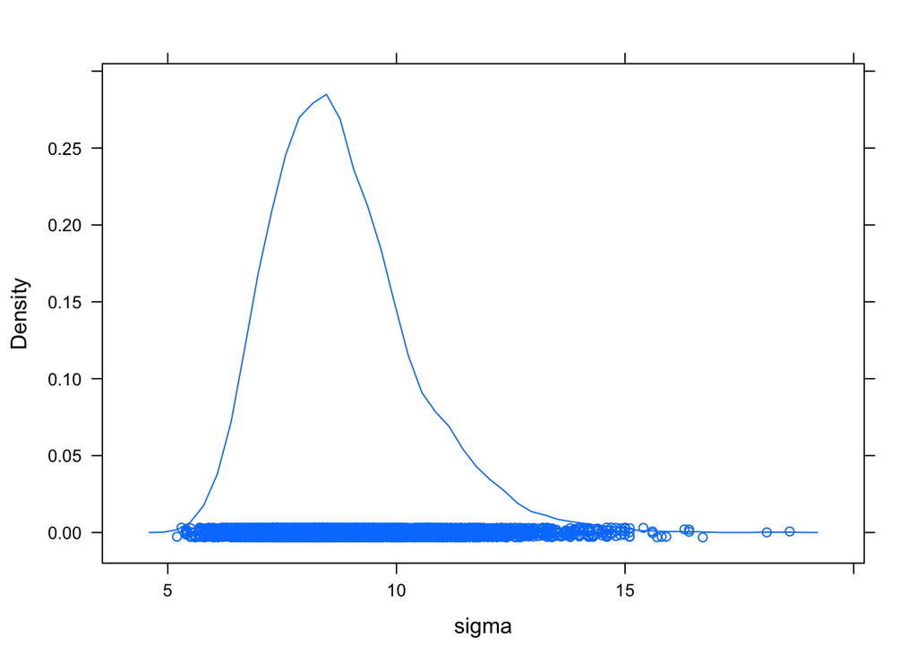

```r
densityplot( ~ sigma, data = Howell20.post)
```

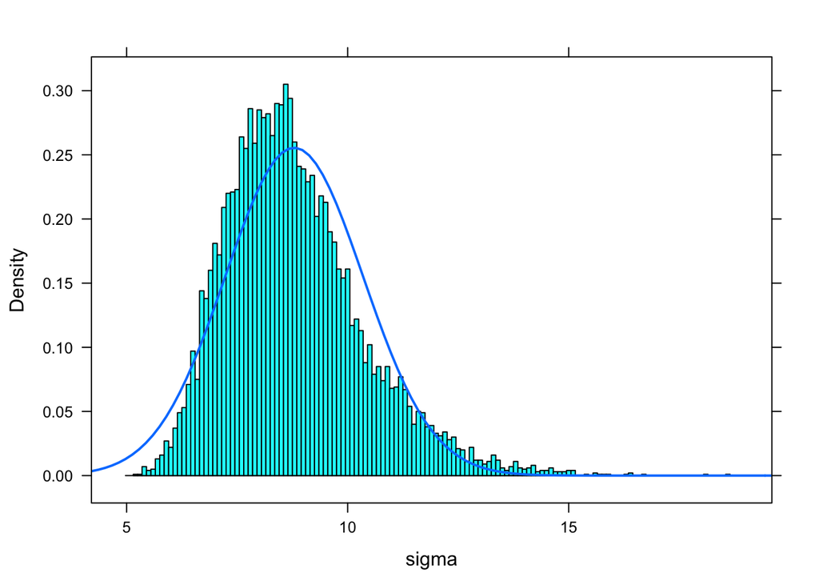

```r
histogram( ~ sigma, data = Howell20.post, width = 0.1, fit = "normal")
```

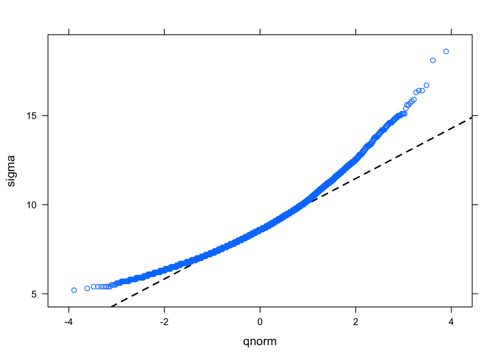

```r
xqqmath( ~ sigma, data = Howell20.post)
```

## Using map() to fit a Bayesian model

```r
flist <-
  alist(
    height ~ dnorm(mu, sigma),
    mu ~ dnorm(178, 20),
    sigma ~ dunif(0, 50))
```

```r
m4.1 <- map(flist, data = HowellAdults)
```

```r
precis(m4.1)      # precis means summary
```

```
##         Mean StdDev   5.5%  94.5%
## mu    154.61   0.41 153.95 155.27
## sigma   7.73   0.29   7.27   8.20
```

```r
vcov(m4.1)
```

```
##                 mu        sigma
## mu    0.1697396109 0.0002180299
## sigma 0.0002180299 0.0849058240
```

```r
sqrt(diag(vcov(m4.1)))
```

```
##        mu     sigma
## 0.4119947 0.2913860
```

Sometimes it is handy to provide starting values for the search. The default is to randomly sample from the priors. But we could use the mean and standard deviation from the data instead.

```r
start <-
  list(
    mu  = mean( ~ height, data = HowellAdults),
    sigma = sd( ~ height, data = HowellAdults))

m4.1a <-
  map(
    alist(height ~ dnorm(mu, sigma),
              mu ~ dnorm(178, 0.1),
           sigma ~ dunif(0, 50)),
           start = start,
           data = HowellAdults)
```

## Using a highly informative prior

If we reduce the standard deviation of the prior for $\mu$, the prior has a much bigger impact on the posterior.

```r
m4.2 <- map(alist(height ~ dnorm(mu, sigma),
                      mu ~ dnorm(178, 0.1),
                   sigma ~ dunif(0, 50)),
            data = HowellAdults)
precis(m4.2)
```

```
##         Mean StdDev   5.5%  94.5%
## mu    177.86   0.10 177.70 178.02
## sigma  24.52   0.93  23.03  26.00
```

```r
mean( ~ height, data = HowellAdults)
```

```
## [1] 154.5971
```

### Variance-Covariance

The quadratic approximation is based on using a multivariate normal distribution to approxiamte the posterior.

```r
precis(m4.1)
```

```
##         Mean StdDev   5.5%  94.5%
## mu    154.61   0.41 153.95 155.27
## sigma   7.73   0.29   7.27   8.20
```

```r
vcov(m4.1)
```

```
##                 mu        sigma
## mu    0.1697396109 0.0002180299
## sigma 0.0002180299 0.0849058240
```

```r
diag(vcov(m4.1))
```

```
##         mu      sigma
## 0.16973961 0.08490582
```

```r
sqrt(diag(vcov(m4.1)))
```

```
##        mu     sigma
## 0.4119947 0.2913860
```

```r
cov2cor(vcov(m4.1))
```

```
##                mu       sigma
## mu    1.000000000 0.001816167
## sigma 0.001816167 1.000000000
```

## Extracting posterior samples from a map model

We could use the information from `vcov()` and `rmvnorm()` or `mvrnorm()` to create posterior samples. But `extract.samples()` does this all for us.

```r
HowellAdults.post <- extract.samples(m4.1, n = 1e4)
head(HowellAdults.post)
```

```
##         mu    sigma
## 1 154.2377 7.353138
## 2 154.4996 7.022478
## 3 154.1569 8.190758
## 4 155.0493 7.461329
## 5 154.4770 7.354709
## 6 154.8488 8.093204
```

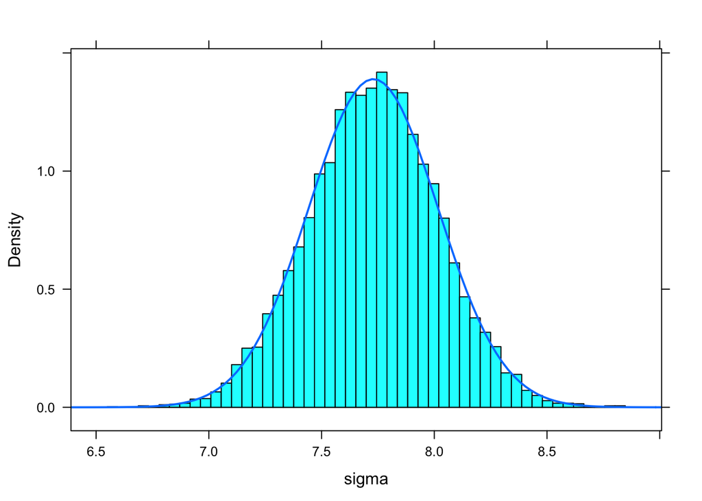

```r
histogram(~sigma, data = HowellAdults.post, n = 50, fit =  "normal")
```

`precis()` uses the posterior samples to provide a summary of each parameter.

```r
precis(HowellAdults.post)
```

```
##         Mean StdDev  |0.89  0.89|
## mu    154.60   0.41 153.96 155.26
## sigma   7.73   0.29   7.27   8.19
```

## Improving the approximation

The posterior distribution for $\sigma$ is not normal.  
(This was especially clear when we looked a small sample using the grid method. For larger samples, it’s pretty close to normal.)

The posterior for $\log(\sigma)$ is better approximated by a normal distribution. We can fit that model by adding in a transformation of the parameter. This also removes he need to artificially cut of the range of possible values for $\sigma$ (using a uniform distribution, for example).

Our small sample shows the effect more clearly.

```r
m4.1_logsigma <-
  map(
    alist(
      height ~ dnorm(mu, exp(log_sigma)),
      mu ~ dnorm(178, 20),
      log_sigma ~ dnorm(2, 10)
    ), data = Howell20)
```

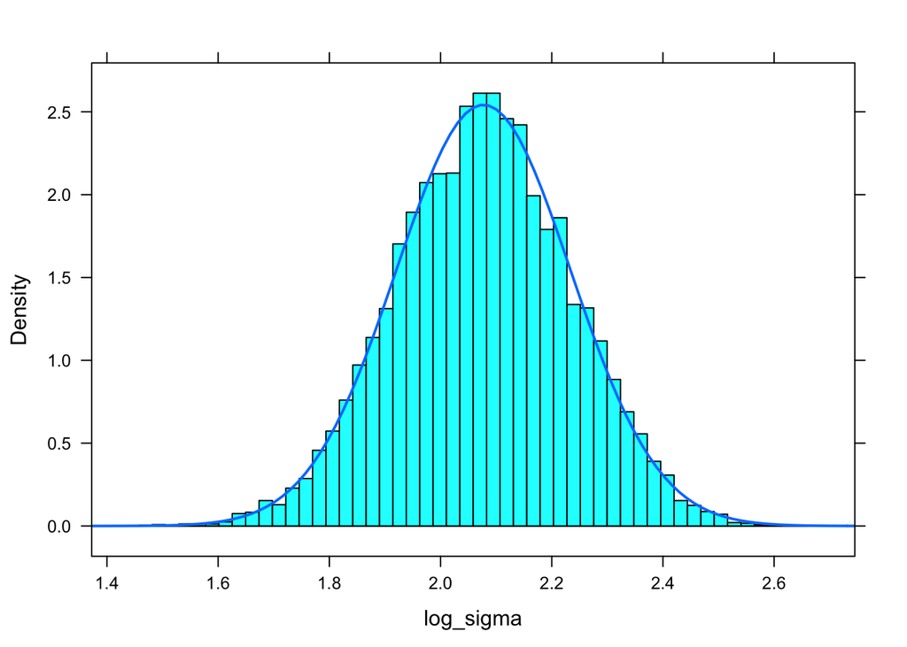

```r
HowellAdults.post2 <-
  extract.samples(m4.1_logsigma) %>%
  mutate(sigma = exp(log_sigma))

histogram( ~ log_sigma, data = HowellAdults.post2, n = 50, fit =  "normal")
```

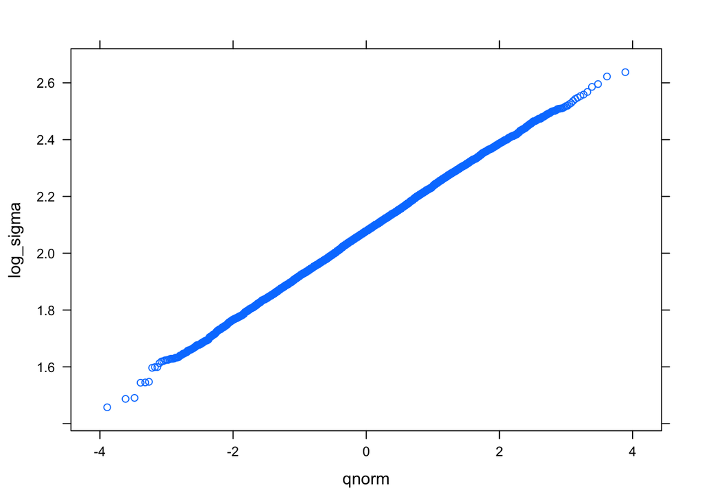

```r
qqmath( ~ log_sigma, data = HowellAdults.post2)
```

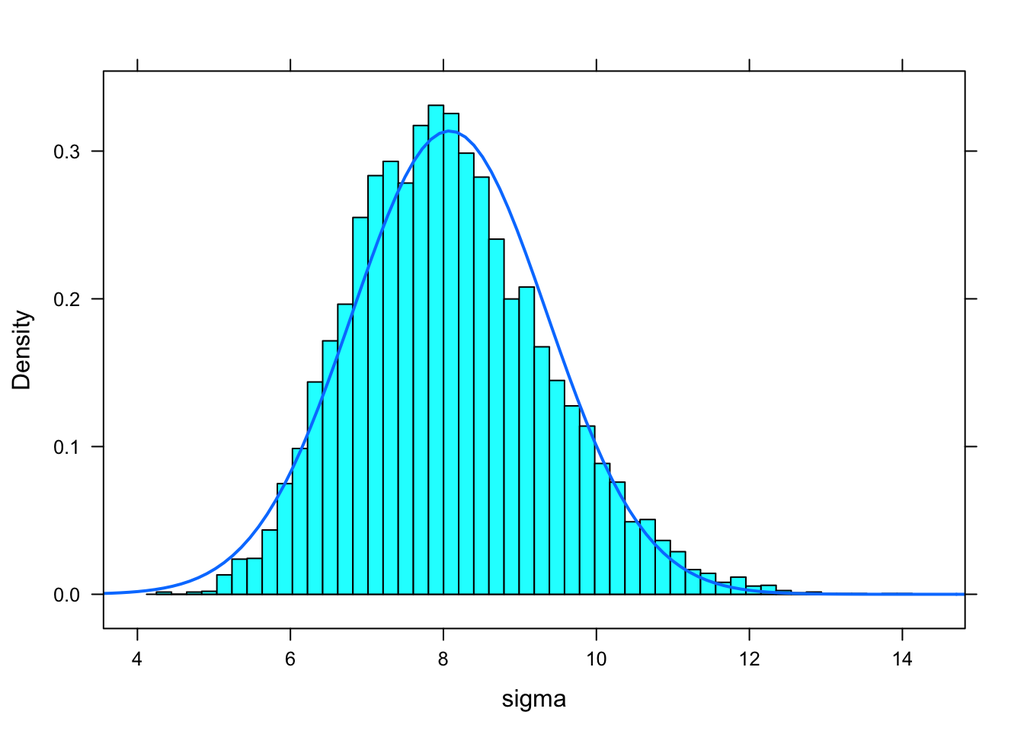

```r
histogram( ~ sigma, data = HowellAdults.post2, n = 50, fit =  "normal")
```

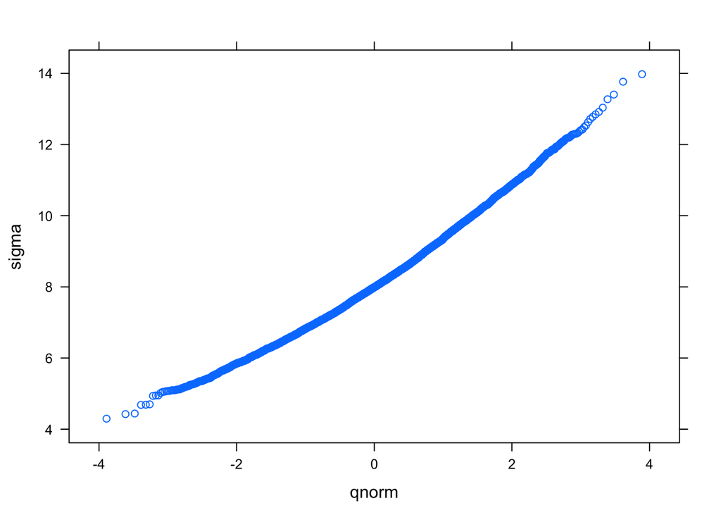

```r
qqmath( ~ sigma, data = HowellAdults.post2)
```

## Adding in a Predictor: sex

```r
howellMaleModel <-
  map(
    alist(
      height ~ dnorm(mu, sigma),
         mu <- a + b * male,
           a ~ dnorm(160, 20),
           b ~ dnorm(25, 15),
       sigma ~ dunif(0, 50)
    ),
    data = HowellAdults)
```

```r
HowellMalePost <-
  howellMaleModel %>% extract.samples()
head(HowellMalePost)
```

```
##          a        b    sigma
## 1 149.7394 10.68779 5.140140
## 2 149.3933 10.80575 5.830715
## 3 149.3616 11.36553 5.684810
## 4 148.9562 11.37057 5.526154
## 5 149.3269 10.71114 5.405222
## 6 149.5597 10.89864 5.418401
```

```r
precis(HowellMalePost)
```

```
##         Mean StdDev  |0.89  0.89|
## a     149.50   0.40 148.88 150.16
## b      10.86   0.59   9.92  11.83
## sigma   5.52   0.21   5.20   5.85
```

```r
mean(height ~ male, data = HowellAdults)
```

```
##        0        1
## 149.5135 160.3585
```

## Birth order and sex

This is a brief interlude to look at the data used in the problems at the end of Chapter 3.

### Looking at the data

```r
# load the birth1 and birth2 data vectors
data(homeworkch3, package = "rethinking")
# put them into a data frame
Birth <- data_frame(
  first = birth1,
  second = birth2
)
# tally up the counts
tally( ~ first + second, data = Birth, margins = TRUE)
```

```
##        second
## first     0   1 Total
##   0      10  39    49
##   1      30  21    51
##   Total  40  60   100
```

```r
# How many boys (both births)?
30 + 39 + 21 * 2
```

```
## [1] 111
```

### Fitting the model using map()

For your homework, you were supposed to use the grid method. Here, I’m using `map()` instead.

```r
BirthSex.map <-
  map(
    alist(
      boys ~ dbinom(size = 200, prob = p),
      p ~ dunif(0, 1)
    ),
    data = list(boys = 111)
  )

BirthSex.post <-
  extract.samples(BirthSex.map, 1e5)
```

Once you have created posterior samples, things are the same either way. Since we are using `map()` here, the posterior distribution of `p` will be normal – that’s an assumption behind how `map()` works. So this is neither informative nor surprising. (You could see how well a normal distribution fits the posterior that results from the grid method. If the fit is poor, then `map()` probably isn’t a good choice for this situation.)

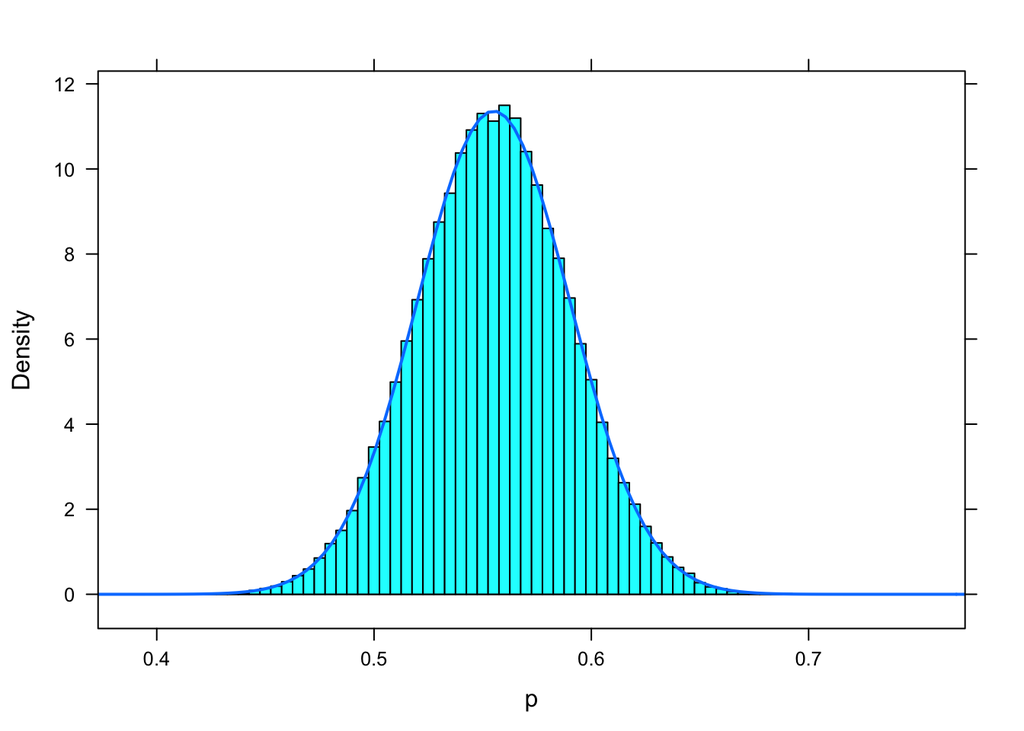

```r
histogram( ~ p, data = BirthSex.post, width = 0.005, fit = "normal")
```

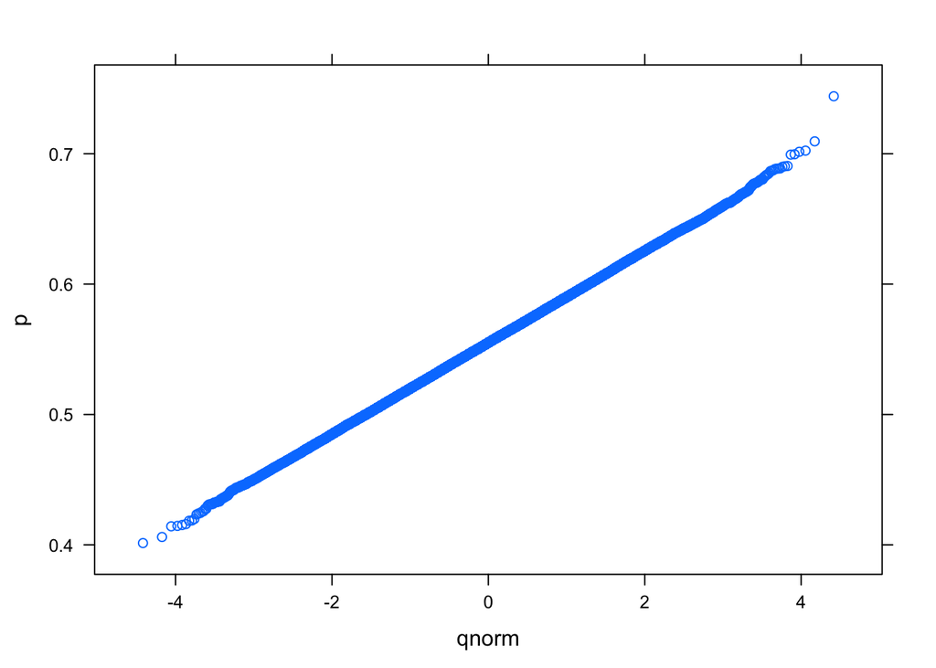

```r
qqmath( ~ p, data = BirthSex.post)
```

The posterior samples can be used to check the model in various ways. For example, since the model assumes that all the births are independent and have the same probability of being male, any subset of the births should look reasonable under this assumption.

The homework asks you to check a few things. Here is another. Let’s consider whether 21 is a reasonable number of families to have two boys. If $p$ is the true proportion of boys, and births are independent, then $p^2$ should be the proportion of families with two boys.

For example, let’s consider

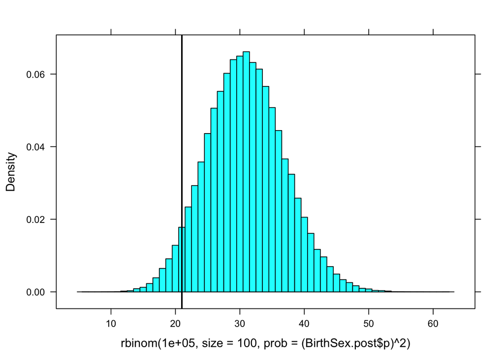

```r
# samples of size 100 (100 families)
histogram( ~ rbinom(1e5, size = 100, prob = (BirthSex.post$p)^2),
           width = 1, v = 21)
```

The observed value of 21 is a little low, but not extremely so – enough to cause us to pause, but not enough to force us to throw out the model (at least not by itself).

```r
prop( ~ (rbinom(1e5, size = 100, prob = (BirthSex.post$p)^2) <= 21))
```

```
##    TRUE
## 0.05327
```